# Lecture 11 + R Demo

Sam Ventura

October 5th, 2016

# Scatterplots!

So far, we’ve used the following data types within a single graphic:

- 1-D Categorical
- 2-D Categorical
- 3+D Categorical (with facets)
- 1-D Continuous
- Mixing Categorical and 1-D Continuous

Now, we’ll be looking at 2-D continuous, 3+D Continuous, and other high-dimensional data scenarios.

**The graphs below don’t have proper titles, axis labels, legends, etc. Please take care to do this on your own graphs.**

# Geometry

We use `geom_point()` to generate scatterplots.

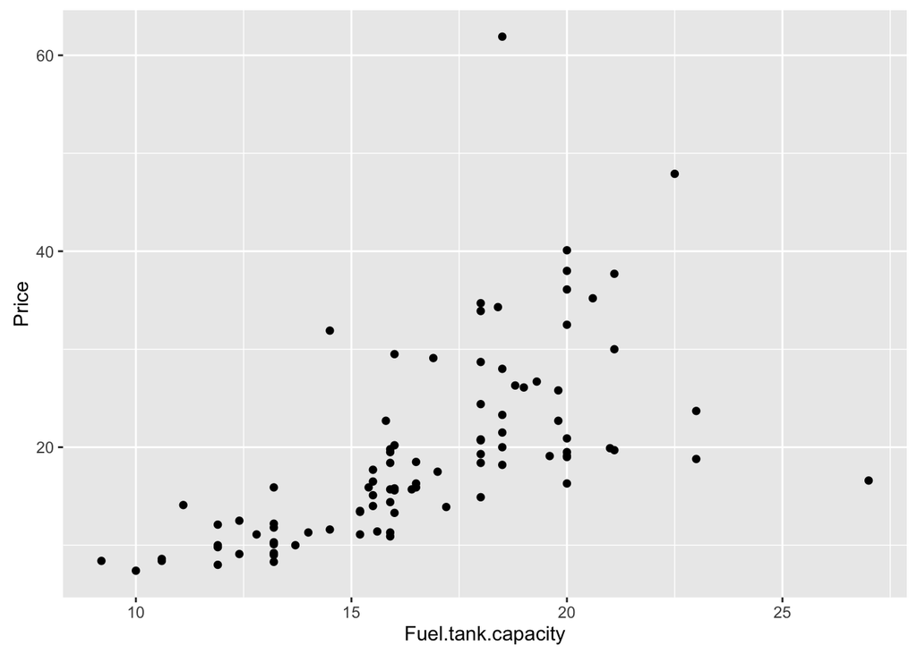

```r
library(MASS)
library(ggplot2)
data(Cars93)
#head(Cars93)

ggplot(Cars93) + aes(x = Fuel.tank.capacity, y = Price) +
  geom_point()
```

# Aesthetics

## Colors

We can color by a third variable, whether it’s categorical (different color for each category):

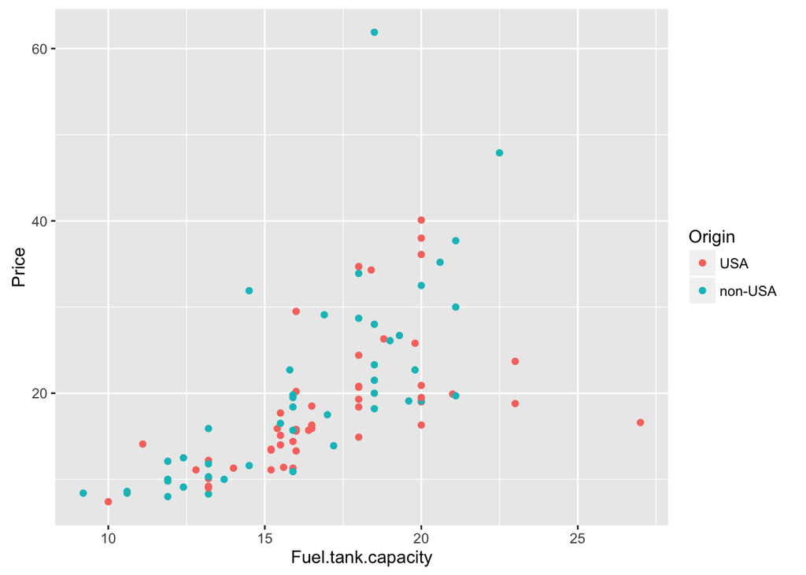

```r
ggplot(Cars93) + aes(x = Fuel.tank.capacity, y = Price) +
  geom_point(aes(colour = Origin))
```

…or continuous (with a color scale/gradient):

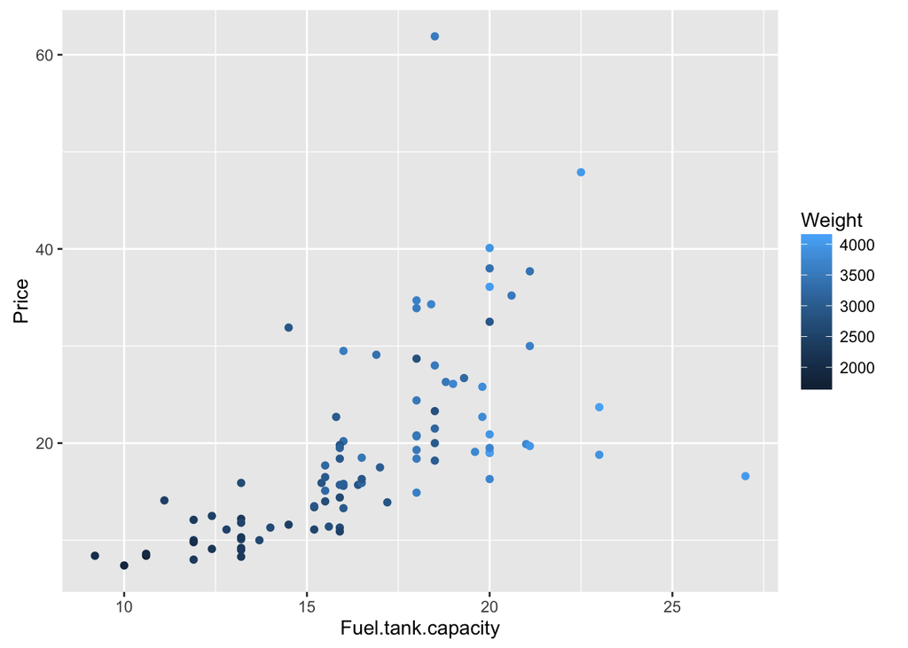

```r
ggplot(Cars93) + aes(x = Fuel.tank.capacity, y = Price) +
  geom_point(aes(colour = Weight))
```

## Point size (`size`)

We can also map variables to other aesthetics, e.g. `size`:

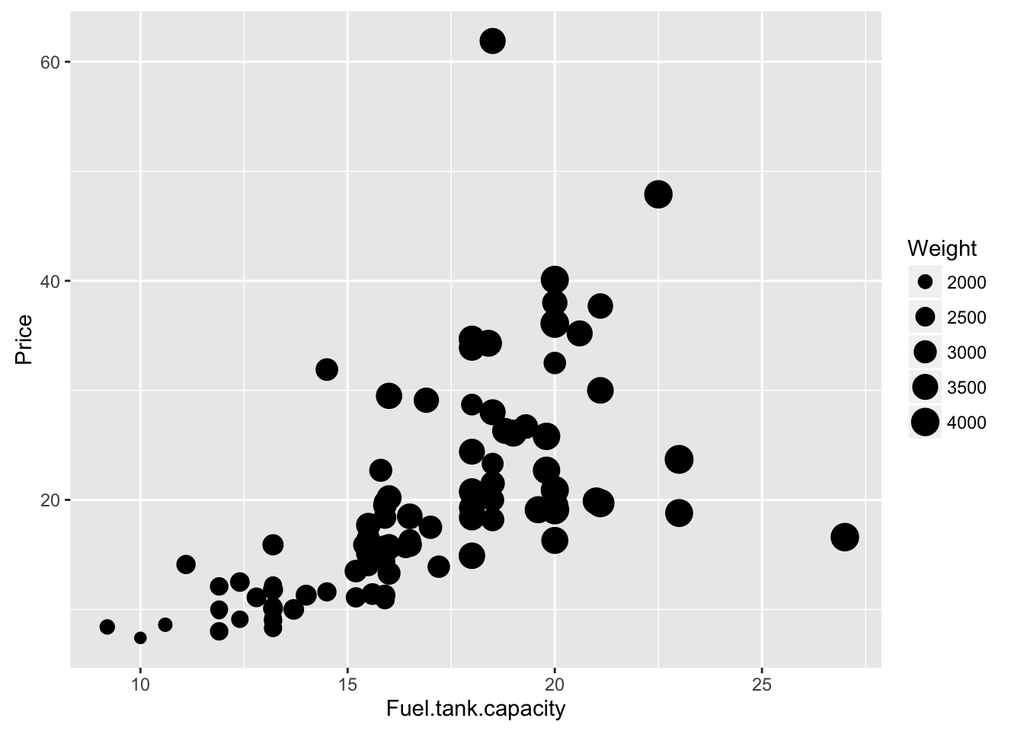

```r
ggplot(Cars93) + aes(x = Fuel.tank.capacity, y = Price) +
  geom_point(aes(size = Weight))
```

## Point type (`shape`)

… or the type (`shape`) of points:

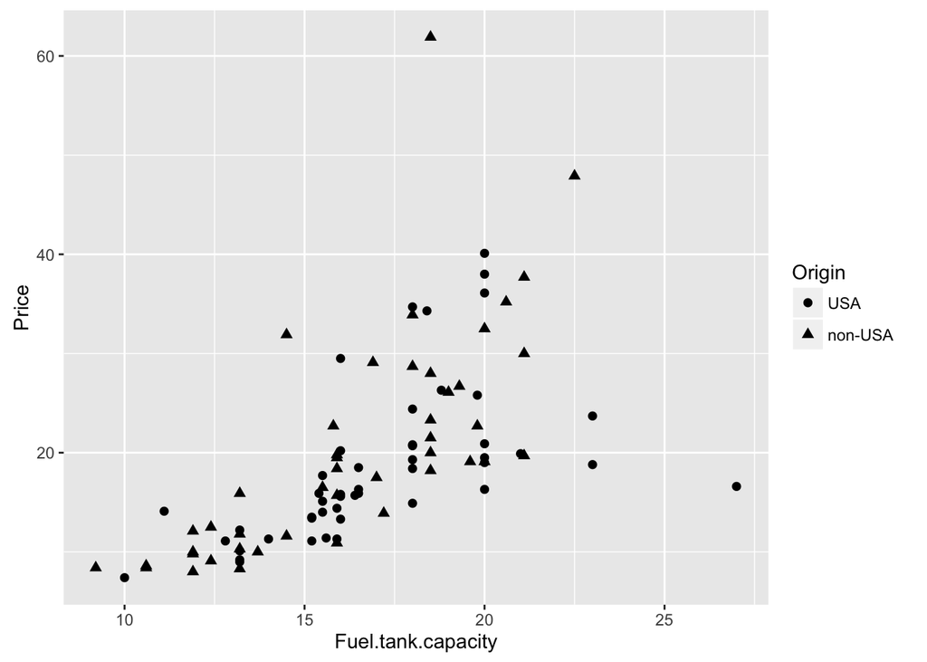

```r
ggplot(Cars93) + aes(x = Fuel.tank.capacity, y = Price) +
  geom_point(aes(shape = Origin), size = 2)
```

## Point shading (`alpha`)

… or the shading (`alpha`) of the points:

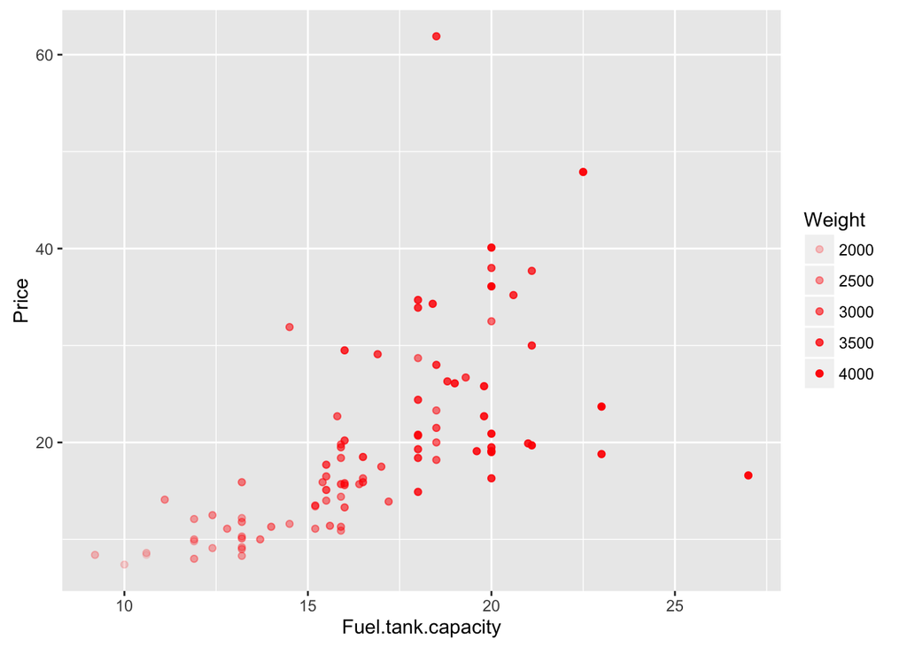

```r
ggplot(Cars93) + aes(x = Fuel.tank.capacity, y = Price) +
  geom_point(aes(alpha = Weight), color = "red")
```

## Combining aesthetics

We can even do several of these at once:

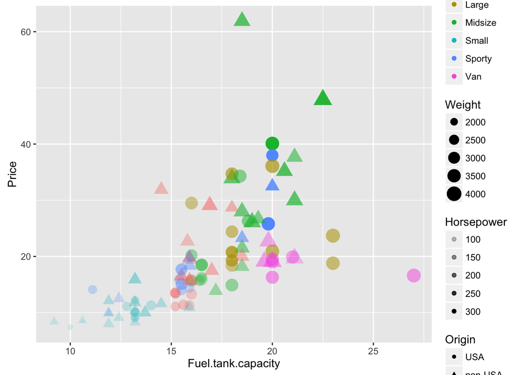

```r
ggplot(Cars93) + aes(x = Fuel.tank.capacity, y = Price) +
  geom_point(aes(size = Weight, color = Type, shape = Origin,
                 alpha = Horsepower))
```

The above graph is actually a 6-dimensional graphic:

- `x` = Fuel tank capacity
- `y` = Price
- `color` = Car type
- `size` = Weight
- `shape` = Origin
- `alpha` = Horsepower

## Mixing point types

Mixing point types is an easy way to make (aesthetically) nice looking graphics!

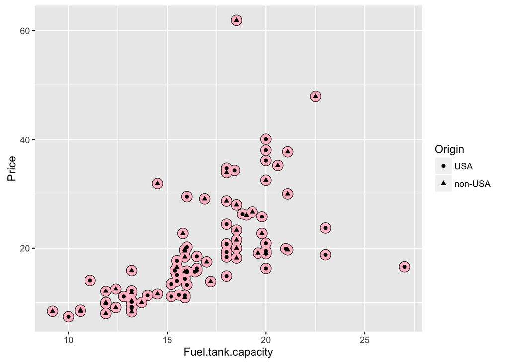

```r
ggplot(Cars93) + aes(x = Fuel.tank.capacity, y = Price) +
  geom_point(colour="black", size = 4.5) +
  geom_point(colour="pink", size = 4) +
  geom_point(aes(shape = Origin))
```

### But be careful!

The more complications you add, the more difficult your graph is to explain.

# Trend Lines

We can do different forms of statistical modeling **within our plots** (e.g. with `geom_smooth()`).

For example, we can add a linear regression line to our plot very easily.

## Linear regression

To do this, we can use `+ geom_smooth(method = lm)`:

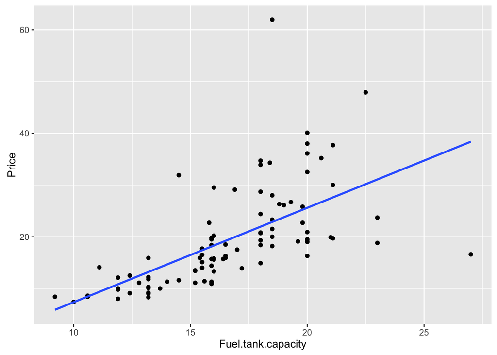

```r
ggplot(Cars93) + aes(x = Fuel.tank.capacity, y = Price) +
  geom_point() + geom_smooth(method = lm, se = FALSE)
```

## Linear regression (with error bars)

Above, I added `se = FALSE` so that the standard error bars do not show up in the graph. Setting this parameter to `TRUE` instead, we get:

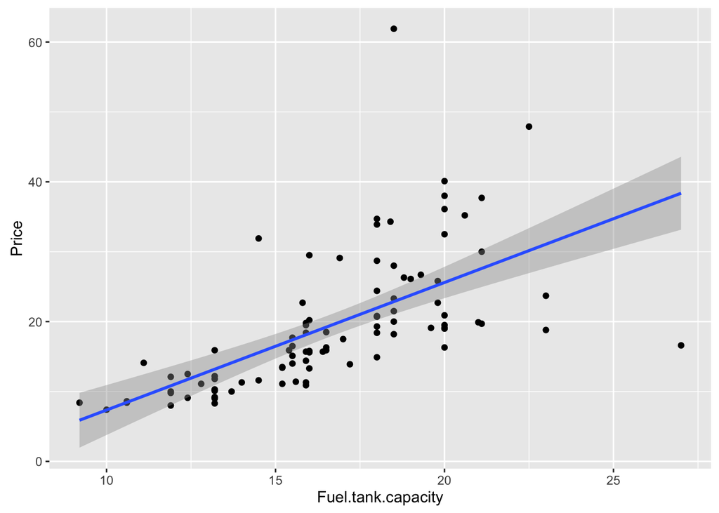

```r
ggplot(Cars93) + aes(x = Fuel.tank.capacity, y = Price) +
  geom_point() + geom_smooth(method = lm, se = TRUE)
```

This isn’t a very good fit (e.g. look at residuals vs. fitted), so perhaps a variable transformation will help.

## Variable Transformations

### Log Transform

We can transform continuous variables as well – again, **within the plot**.

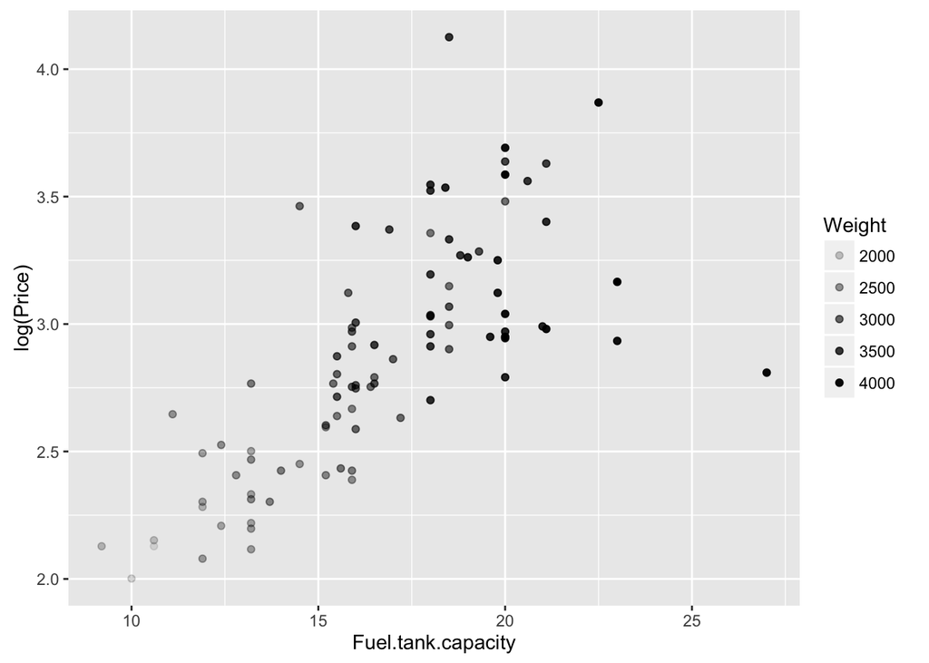

```r
ggplot(Cars93) + aes(x = Fuel.tank.capacity, y = log(Price)) +
  geom_point(aes(alpha = Weight))
```

### Regression with Transformations

Sometimes, variable transformations (e.g. `log()` or `sqrt()`) are useful when we’re doing linear regression, in order to get a better fit

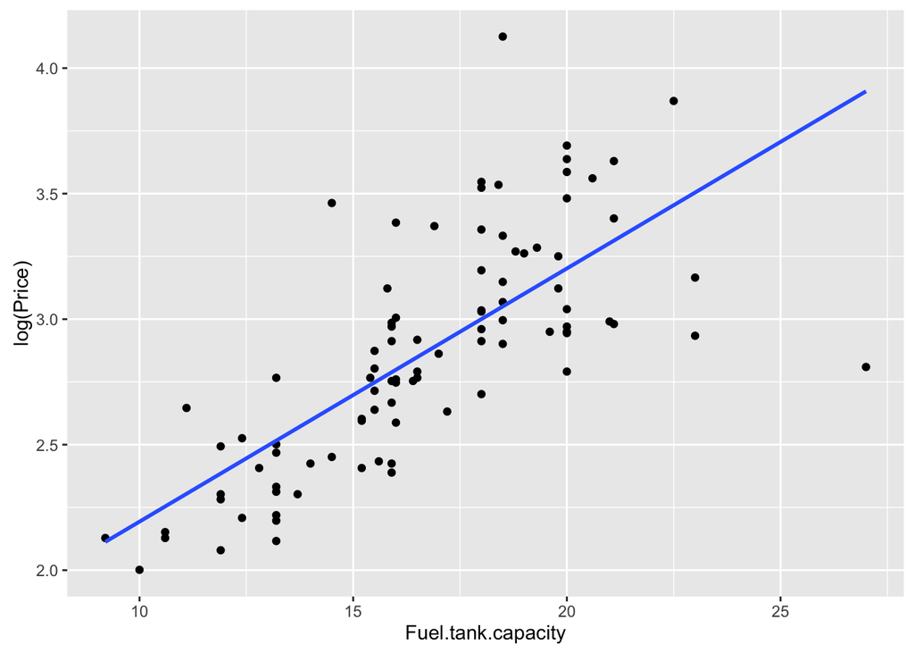

```r
ggplot(Cars93) + aes(x = Fuel.tank.capacity, y = log(Price)) +
  geom_point() + geom_smooth(method = lm, se = FALSE)
```

### SEs with Transformations

I added `se = FALSE` so that the standard error bars do not show up in the graph. Setting this parameter to `TRUE` instead, we get:

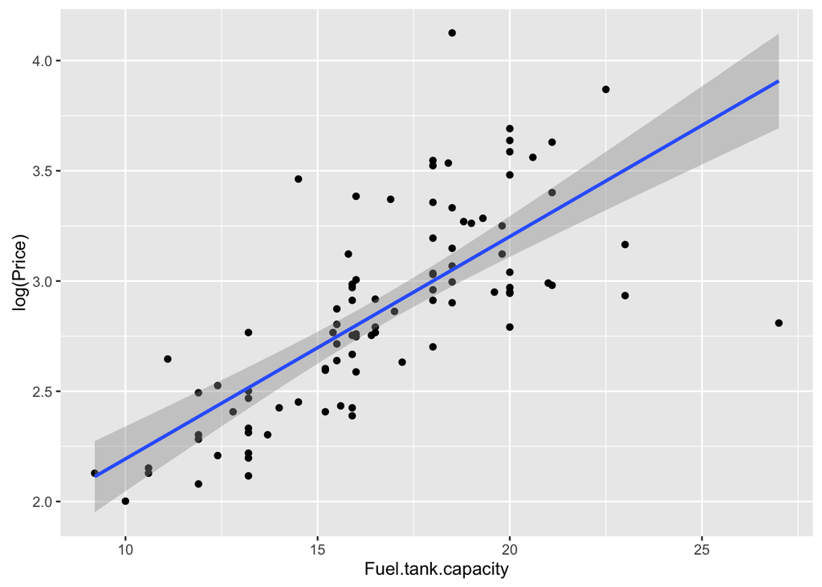

```r
ggplot(Cars93) + aes(x = Fuel.tank.capacity, y = log(Price)) +
  geom_point() + geom_smooth(method = lm, se = TRUE)
```

### Adjusting SE Bars

We can specify different alpha-levels for our confidence bands in liner regression. The default is 0.95. What if we changed it to 0.9? 0.99?

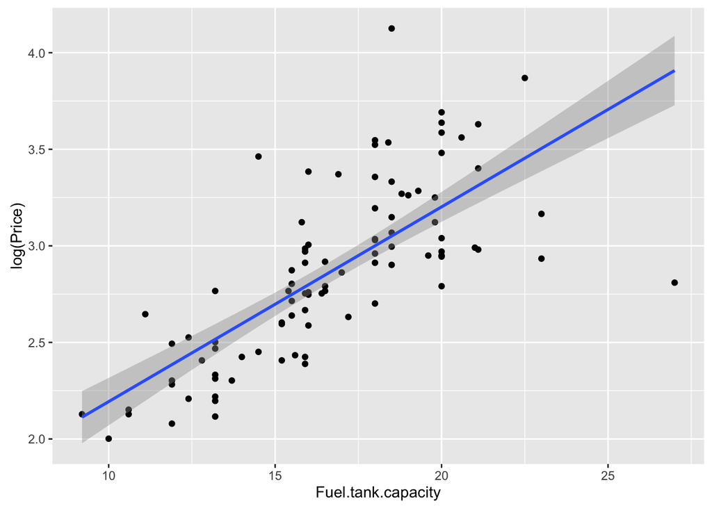

```r
ggplot(Cars93) + aes(x = Fuel.tank.capacity, y = log(Price)) +
  geom_point() + stat_smooth(method = lm, se = TRUE, level = 0.9)
```

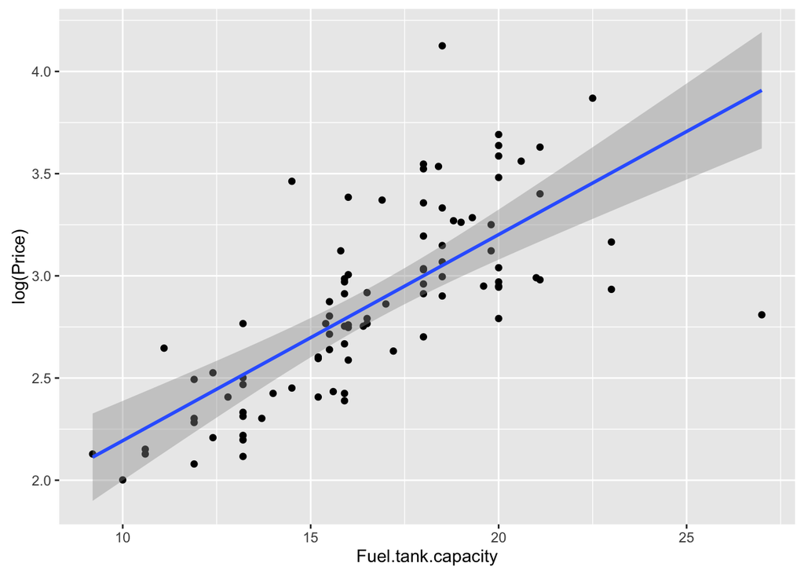

```r
ggplot(Cars93) + aes(x = Fuel.tank.capacity, y = log(Price)) +
  geom_point() + stat_smooth(method = lm, se = TRUE, level = 0.99)
```

## Non-Linear Trends

We can also do other types of modeling, e.g. local regression / loess smoothing

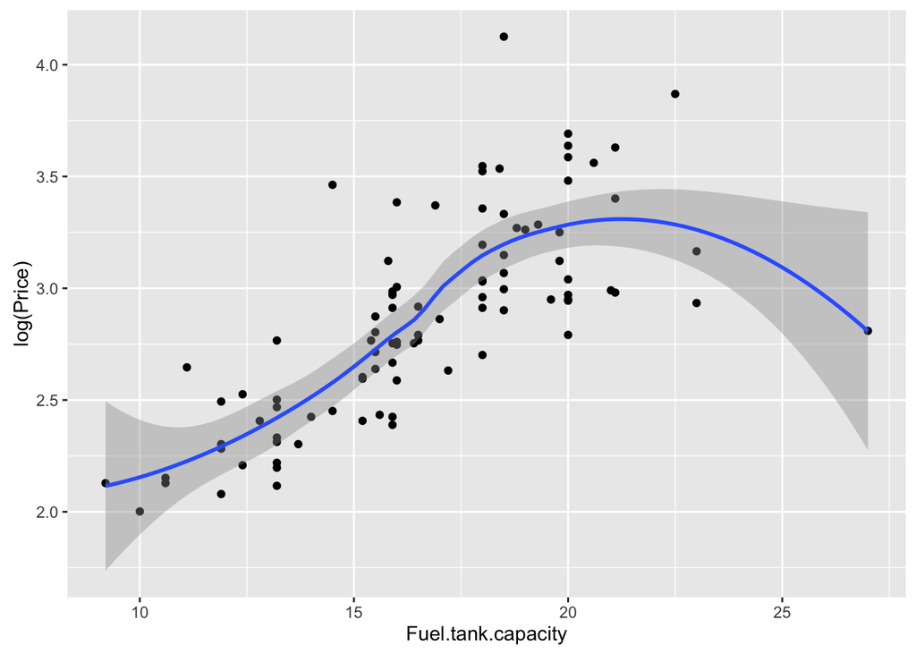

```r
ggplot(Cars93) + aes(x = Fuel.tank.capacity, y = log(Price)) +
  geom_point() + geom_smooth(method = loess, se = TRUE)
```

## Leave The Points. Take The Regression Model.

We don’t even need to plot the points to do this – sometimes we might want to just plot the regression model:

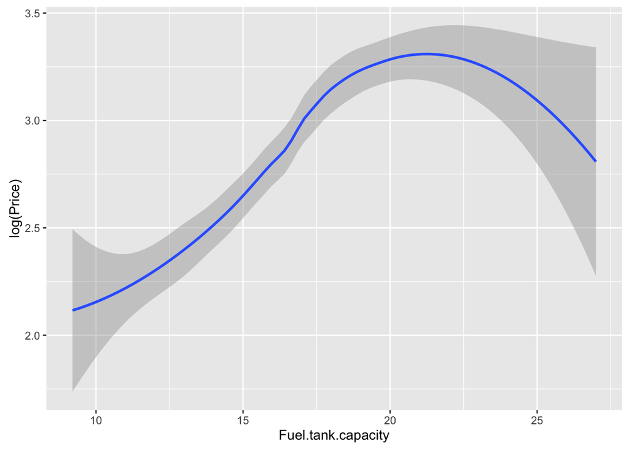

```r
ggplot(Cars93) + aes(x = Fuel.tank.capacity, y = log(Price)) +
  geom_smooth(method = loess, se = TRUE)
```

As always, can adjust some parameters:

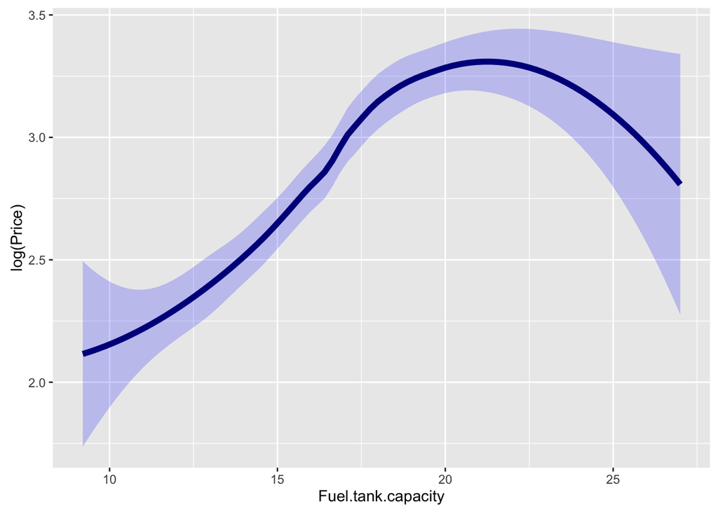

```r
ggplot(Cars93) + aes(x = Fuel.tank.capacity, y = log(Price)) +
  geom_smooth(method = loess, se = TRUE, fill = "blue",
              colour = "darkblue", size = 2, alpha = 0.2)
```

# Next time:

- Pairs plots
- Don’t forget about marginal distributions!
- 2-D Kernel Density Estimation
- Heat Maps